# Supplementary Material - Growth mindset and mindfulness inductions to facilitate effort after negative feedback

Data processing is available in “script/data_processing.R”.

# S1. Exploratory factor analysis of the expriences after the experiment

After the last IQ performance was measured, we asked nine questions from the participants about their experiences during the study. We used exploratory factor analysis to extract the main factors from these questions. Based on multiple factor number estimating methods, we chose a three factor solution.

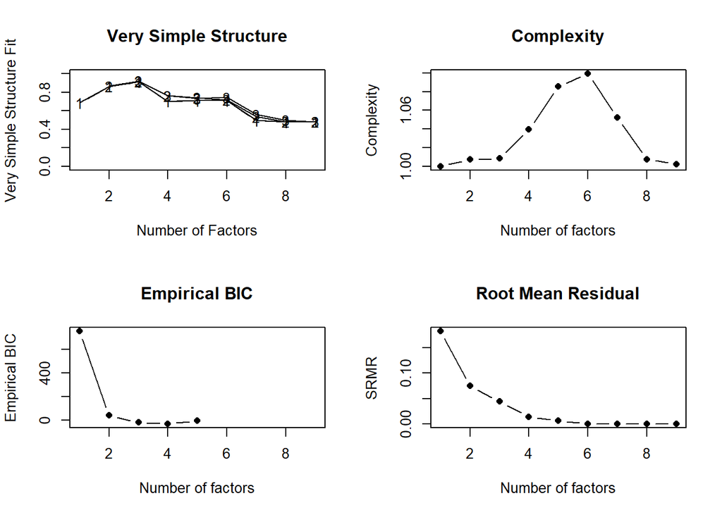

```
##
## Number of factors
## Call: vss(x = x, n = n, rotate = rotate, diagonal = diagonal, fm = fm,
##     n.obs = n.obs, plot = FALSE, title = title, use = use, cor = cor,
##     max.iter = 500)
## VSS complexity 1 achieves a maximimum of 0.91  with  3  factors
## VSS complexity 2 achieves a maximimum of 0.92  with  3  factors
## The Velicer MAP achieves a minimum of 0.07  with  2  factors
## Empirical BIC achieves a minimum of  -30.24  with  4  factors
## Sample Size adjusted BIC achieves a minimum of  7.14  with  5  factors
##
## Statistics by number of factors
##   vss1 vss2   map dof   chisq     prob sqresid  fit RMSEA   BIC SABIC complex
## 1 0.69 0.00 0.082  27 7.2e+02 2.7e-134     6.7 0.69  0.26 559.2 644.9     1.0
## 2 0.86 0.87 0.068  19 3.5e+02  3.0e-62     2.9 0.87  0.21 234.7 295.0     1.0
## 3 0.91 0.92 0.122  12 2.4e+02  6.2e-44     1.7 0.92  0.22 165.9 203.9     1.0
## 4 0.70 0.76 0.133   6 2.9e+01  6.4e-05     5.1 0.76  0.10  -6.8  12.2     1.0
## 5 0.71 0.74 0.181   1 9.9e+00  1.6e-03     5.3 0.75  0.15   4.0   7.1     1.1
## 6 0.71 0.72 0.302  -3 1.0e-05       NA     5.1 0.76    NA    NA    NA     1.1
## 7 0.49 0.54 0.482  -6 4.0e-08       NA     9.5 0.56    NA    NA    NA     1.1
## 8 0.48 0.48 1.000  -8 2.3e-11       NA    10.8 0.49    NA    NA    NA     1.0
## 9 0.48 0.48    NA  -9 0.0e+00       NA    11.0 0.48    NA    NA    NA     1.0
##    eChisq    SRMR eCRMS  eBIC
## 1 9.1e+02 1.8e-01 0.210 754.4
## 2 1.5e+02 7.5e-02 0.103  41.0
## 3 5.4e+01 4.4e-02 0.076 -17.8
## 4 5.4e+00 1.4e-02 0.034 -30.2
## 5 1.1e+00 6.3e-03 0.038  -4.9
## 6 1.6e-06 7.7e-06    NA    NA
## 7 4.3e-09 3.9e-07    NA    NA
## 8 1.7e-12 7.9e-09    NA    NA
## 9 2.5e-27 3.0e-16    NA    NA
```

Five questions loaded to the first factor (stress), and three questions loaded to the second factor (task boredom). Only one item loaded to the third factor, that we didn’t analyze. Factor scores for task boredom and stress were calculated using the regression method, and were used in the later analyses.

EFA Factor loadings

|  | Factor 1 | Factor 2 | Factor 3 | Communality |
| --- | --- | --- | --- | --- |
| How boring was the IQ test for you? | 0.03 | 0.96 | 0.02 | 0.91 |
| How exciting was the IQ test for you? | 0.02 | -0.65 | -0.01 | 0.43 |
| How bored were you filling the survey? | -0.04 | 0.76 | -0.03 | 0.59 |
| How nervous were you filling the survey? | 0.82 | -0.07 | 0.06 | 0.72 |
| How stressful did you find the IQ test? | 0.86 | -0.01 | 0.05 | 0.77 |
| How calm were you during the IQ test? | -0.79 | -0.01 | 0.04 | 0.62 |
| Did stress affect your performance on the IQ test? | 0.83 | -0.01 | -0.02 | 0.66 |
| To what extent has stress worsened your performance on the IQ test? | 0.83 | 0.08 | -0.05 | 0.64 |
| How challenging was the IQ test for you? | 0.00 | 0.01 | 0.96 | 0.92 |
| Total Communalities |  |  |  | 6.25 |

# S2. Compare baseline characteristics

## Number of participants in each group, and by gender.

Number of participants by group

| Fixed - Control | Fixed - Mindfulness | Growth - Control | Growth - Mindfulness |
| --- | --- | --- | --- |
| 90 | 102 | 101 | 90 |

Number of participants of each gender by group

| Gender | Fixed - Control | Fixed - Mindfulness | Growth - Control | Growth - Mindfulness |
| --- | --- | --- | --- | --- |
| Female | 74 | 79 | 82 | 71 |
| Male | 16 | 23 | 19 | 19 |

## Compare baseline characterisitcs by group

| Measure | Group Fixed-Control | Group Fixed-Mindfulness | Group Growth-Control | Group Growth-Mindfulness |
| --- | --- | --- | --- | --- |
| Gender: Male | 18.0% | 23.0% | 19.0% | 21.0% |
| Age | 21.94 (2.38) | 22.28 (4.33) | 22.86 (4.89) | 22.14 (4.63) |
| Prior growth mindset | 4.02 (1.03) | 3.90 (1.10) | 4.14 (0.93) | 3.97 (1.07) |
| Trait mindfulness | 2.80 (0.39) | 2.78 (0.46) | 2.84 (0.40) | 2.83 (0.38) |
| Ego-resilience | 2.78 (0.50) | 2.78 (0.42) | 2.87 (0.48) | 2.77 (0.43) |
| Grit | 2.73 (0.68) | 2.65 (0.75) | 2.63 (0.70) | 2.62 (0.67) |
| Self-compassion | 3.00 (0.64) | 2.98 (0.66) | 3.00 (0.58) | 3.00 (0.65) |
| Global self-esteem | 1.92 (0.52) | 2.04 (0.57) | 2.08 (0.55) | 2.04 (0.54) |

None of the groups differed in any trait characteristics. The following table shows the results of the linear models that were used for the comparisons.

| term | estimate | std.error | statistic | p.value |
| --- | --- | --- | --- | --- |
| Gender: Male |  |  |  |  |
| (Intercept) | 0.18 | 0.04 | 4.19 | 0.0000 |
| mindsetGrowth | 0.01 | 0.06 | 0.18 | 0.8594 |
| interventionMindfulness | 0.05 | 0.06 | 0.82 | 0.4129 |
| mindsetGrowth:interventionMindfulness | −0.02 | 0.08 | −0.30 | 0.7644 |
| Age |  |  |  |  |
| (Intercept) | 21.94 | 0.44 | 49.50 | 0.0000 |
| mindsetGrowth | 0.92 | 0.61 | 1.50 | 0.1334 |
| interventionMindfulness | 0.34 | 0.61 | 0.56 | 0.5766 |
| mindsetGrowth:interventionMindfulness | −1.06 | 0.86 | −1.23 | 0.2205 |
| Prior growth mindset |  |  |  |  |
| (Intercept) | 4.02 | 0.11 | 36.95 | 0.0000 |
| mindsetGrowth | 0.12 | 0.15 | 0.80 | 0.4262 |
| interventionMindfulness | −0.12 | 0.15 | −0.80 | 0.4221 |
| mindsetGrowth:interventionMindfulness | −0.05 | 0.21 | −0.25 | 0.8057 |
| Trait mindfulness |  |  |  |  |
| (Intercept) | 2.80 | 0.04 | 64.71 | 0.0000 |
| mindsetGrowth | 0.04 | 0.06 | 0.66 | 0.5102 |
| interventionMindfulness | −0.02 | 0.06 | −0.35 | 0.7302 |
| mindsetGrowth:interventionMindfulness | 0.02 | 0.08 | 0.20 | 0.8448 |
| Ego-resilience |  |  |  |  |
| (Intercept) | 2.78 | 0.05 | 57.48 | 0.0000 |
| mindsetGrowth | 0.09 | 0.07 | 1.31 | 0.1924 |
| interventionMindfulness | 0.00 | 0.07 | 0.03 | 0.9793 |
| mindsetGrowth:interventionMindfulness | −0.10 | 0.09 | −1.02 | 0.3094 |
| Grit |  |  |  |  |
| (Intercept) | 2.73 | 0.07 | 36.46 | 0.0000 |
| mindsetGrowth | −0.10 | 0.10 | −1.01 | 0.3112 |
| interventionMindfulness | −0.08 | 0.10 | −0.79 | 0.4308 |
| mindsetGrowth:interventionMindfulness | 0.08 | 0.14 | 0.53 | 0.5958 |
| Self-compassion |  |  |  |  |
| (Intercept) | 3.00 | 0.07 | 45.00 | 0.0000 |
| mindsetGrowth | 0.00 | 0.09 | −0.02 | 0.9830 |
| interventionMindfulness | −0.03 | 0.09 | −0.30 | 0.7658 |
| mindsetGrowth:interventionMindfulness | 0.03 | 0.13 | 0.23 | 0.8217 |
| Global self-esteem |  |  |  |  |
| (Intercept) | 1.92 | 0.06 | 33.04 | 0.0000 |
| mindsetGrowth | 0.16 | 0.08 | 1.96 | 0.0505 |
| interventionMindfulness | 0.12 | 0.08 | 1.46 | 0.1442 |
| mindsetGrowth:interventionMindfulness | −0.15 | 0.11 | −1.35 | 0.1789 |

# S3. Determinants of the task performance

Besides pre-induction mindset beliefs and dispositional mindfulness, other individual differences may also play a role in the effect of inductions on task persistence. For example, high ego-resilience is associated with resourcefulness and adaptivity in stressful situations (Farkas & Orosz, 2015). Furthermore, individuals characterized by higher levels of grit — as defined as the trait level of persistence on tasks — were more likely to engage in deliberate practice even after failure (Duckworth et al., 2011). Concurrently, high self-esteem participants persisted more than low self-esteem participants after a single failure(Di Paula & Campbell, 2002). Kernis defined non-contingent self-esteem as self-compassion (Kernis, 2003); thus, it may have a more powerful bolstering effect relating to a failure experience.

## Additional measures

**Grit**. We used the Short Grit Scale (Duckworth et al., 2011) to measure individuals’ tendency to endorse persistence for long-term goals. The scale consists of 8 items such as “I am diligent” (α = .81). Items are rated on a 5-point Likert scale from not like me at all (1) to very much like me (5).

**Ego-Resilience**. The Ego-Resiliency Scale (Farkas & Orosz, 2015) was used to measure the capacity that enables individuals to adapt to constantly changing environmental demands. It consists of 11 items such as “I enjoy dealing with new and unusual situations” (α = .70). Items are rated on a 4-point Likert scale, ranging from does not apply at all (1) to applies very strongly (4).

**Global Self-Esteem**. The Rosenberg Self-Esteem Scale (Rosenberg, 1979) was used to measure global self-esteem. The unifactorial structure is associated with a set of feelings of self-esteem and self-acceptance that evaluates overall self-esteem. This scale consists of 10-items such as “On the whole, I am satisfied with myself”. In our study, we accidentally left out one item from the questionnaire: “I certainly feel useless at times”. However, this did not affect the good internal reliability of the scale (α = .89). Items are rated on a 4-point Likert scale from strongly disagree (1) to strongly agree (4).

**Self-Compassion**. The Short Self-Compassion Scale (Raes et al., 2011) is a 12-item measure assessing the ability to show kindness and humanity towards ourselves when facing undesirable experiences. Participants indicated how often they behave in a certain way like “When I’m going through a very hard time, I give myself the caring and tenderness I need” (α = .81). Items are rated on a 5-point Likert scale from almost never (1) to almost always (5).

The table below shows the the moderating effect of trait characteristics of the aforementioned constructs on the relationship between the inductions and task persistence. We found no significant effects.

|  | Grit |  |  |  | Ego-resilience |  |  |  | Self-compassion |  |  |  | Global self-esteem |  |  |  |
| --- | --- | --- | --- | --- | --- | --- | --- | --- | --- | --- | --- | --- | --- | --- | --- | --- |
| Predictors | Incidence Rate Ratios | CI | Statistic | p | Incidence Rate Ratios | CI | Statistic | p | Incidence Rate Ratios | CI | Statistic | p | Incidence Rate Ratios | CI | Statistic | p |
| (Intercept) | 4.45 | 3.48 – 5.69 | 11.95 | **<0.001** | 4.36 | 3.40 – 5.59 | 11.62 | **<0.001** | 4.35 | 3.40 – 5.56 | 11.73 | **<0.001** | 4.45 | 3.48 – 5.70 | 11.85 | **<0.001** |
| mindset [Growth] | 1.15 | 0.88 – 1.49 | 1.04 | 0.300 | 1.18 | 0.91 – 1.53 | 1.23 | 0.220 | 1.14 | 0.88 – 1.48 | 0.99 | 0.324 | 1.18 | 0.91 – 1.54 | 1.26 | 0.207 |
| moderator | 0.98 | 0.76 – 1.27 | -0.14 | 0.888 | 1.08 | 0.85 – 1.37 | 0.64 | 0.525 | 0.91 | 0.74 – 1.11 | -0.93 | 0.353 | 1.06 | 0.84 – 1.34 | 0.49 | 0.622 |
| intervention [Mindfulness] | 0.94 | 0.73 – 1.22 | -0.46 | 0.649 | 0.93 | 0.71 – 1.21 | -0.53 | 0.593 | 0.95 | 0.73 – 1.24 | -0.36 | 0.722 | 0.90 | 0.69 – 1.16 | -0.83 | 0.406 |
| mindset [Growth] * moderator | 0.97 | 0.75 – 1.25 | -0.27 | 0.791 | 0.91 | 0.70 – 1.17 | -0.74 | 0.458 | 0.92 | 0.72 – 1.17 | -0.66 | 0.509 | 0.86 | 0.67 – 1.10 | -1.19 | 0.232 |
| moderator * intervention [Mindfulness] | 0.96 | 0.74 – 1.24 | -0.32 | 0.747 | 1.13 | 0.87 – 1.47 | 0.95 | 0.343 | 1.23 | 0.96 – 1.56 | 1.66 | 0.096 | 1.23 | 0.95 – 1.58 | 1.58 | 0.114 |
| Zero-Inflated Model |  |  |  |  |  |  |  |  |  |  |  |  |  |  |  |  |
| (Intercept) | 0.28 | 0.14 – 0.56 | -3.56 | **<0.001** | 0.26 | 0.12 – 0.56 | -3.44 | **0.001** | 0.27 | 0.13 – 0.57 | -3.49 | **<0.001** | 0.28 | 0.14 – 0.57 | -3.53 | **<0.001** |
| mindset [Growth] | 1.01 | 0.50 – 2.06 | 0.03 | 0.972 | 1.06 | 0.52 – 2.19 | 0.17 | 0.869 | 0.96 | 0.47 – 1.97 | -0.11 | 0.909 | 1.02 | 0.51 – 2.04 | 0.04 | 0.966 |
| moderator | 1.01 | 0.51 – 1.97 | 0.02 | 0.985 | 1.16 | 0.60 – 2.28 | 0.45 | 0.655 | 1.03 | 0.59 – 1.78 | 0.09 | 0.926 | 1.15 | 0.61 – 2.15 | 0.42 | 0.672 |
| intervention [Mindfulness] | 0.93 | 0.45 – 1.95 | -0.18 | 0.858 | 1.01 | 0.49 – 2.08 | 0.04 | 0.969 | 1.00 | 0.48 – 2.09 | 0.01 | 0.992 | 0.99 | 0.49 – 1.99 | -0.04 | 0.970 |
| mindset [Growth] * moderator | 0.97 | 0.48 – 1.96 | -0.09 | 0.926 | 0.87 | 0.43 – 1.78 | -0.37 | 0.711 | 1.12 | 0.58 – 2.19 | 0.34 | 0.732 | 1.07 | 0.54 – 2.12 | 0.20 | 0.842 |
| moderator * intervention [Mindfulness] | 0.49 | 0.23 – 1.03 | -1.87 | 0.061 | 1.38 | 0.68 – 2.79 | 0.90 | 0.369 | 1.48 | 0.75 – 2.92 | 1.14 | 0.254 | 1.21 | 0.60 – 2.41 | 0.53 | 0.595 |
| Observations | 381 |  |  |  | 383 |  |  |  | 383 |  |  |  | 381 |  |  |  |
| R<sup>2</sup> / R<sup>2</sup> adjusted | 0.133 / 0.119 |  |  |  | 0.127 / 0.113 |  |  |  | 0.244 / 0.232 |  |  |  | 0.243 / 0.231 |  |  |  |
| AIC | 1807.297 |  |  |  | 1817.919 |  |  |  | 1815.638 |  |  |  | 1808.473 |  |  |  |
| log-Likelihood | -890.648 |  |  |  | -895.959 |  |  |  | -894.819 |  |  |  | -891.237 |  |  |  |

# S4. Moderators between the inductions and task performance

Here we only found that the score on the “real” IQ test was weakly associated with the grit score (the upper row means the name of the moderator, that is used in the table as “value”).

| term | estimate | conf.low | conf.high | statistic | p.value |
| --- | --- | --- | --- | --- | --- |
| Age |  |  |  |  |  |
| (Intercept) | −0.52 | −2.46 | 1.41 | −0.53 | 0.5943 |
| mindsetGrowth | 1.10 | −1.06 | 3.25 | 1.00 | 0.3171 |
| interventionMindfulness | 1.43 | −0.76 | 3.62 | 1.29 | 0.1990 |
| Age | 0.03 | −0.06 | 0.11 | 0.59 | 0.5579 |
| mindsetGrowth:interventionMindfulness | −1.62 | −4.21 | 0.98 | −1.23 | 0.2210 |
| mindsetGrowth:Age | −0.05 | −0.15 | 0.04 | −1.08 | 0.2811 |
| interventionMindfulness:Age | −0.06 | −0.16 | 0.03 | −1.28 | 0.2029 |
| mindsetGrowth:interventionMindfulness:Age | 0.07 | −0.05 | 0.19 | 1.19 | 0.2363 |
| Dispositional mindfulness |  |  |  |  |  |
| (Intercept) | 0.05 | −0.16 | 0.25 | 0.43 | 0.6704 |
| mindsetGrowth | −0.09 | −0.38 | 0.20 | −0.62 | 0.5355 |
| interventionMindfulness | 0.03 | −0.26 | 0.31 | 0.18 | 0.8571 |
| Dispositional mindfulness | −0.13 | −0.35 | 0.09 | −1.18 | 0.2379 |
| mindsetGrowth:interventionMindfulness | −0.06 | −0.47 | 0.34 | −0.31 | 0.7549 |
| mindsetGrowth:Dispositional mindfulness | 0.19 | −0.10 | 0.49 | 1.28 | 0.2021 |
| interventionMindfulness:Dispositional mindfulness | 0.20 | −0.08 | 0.48 | 1.42 | 0.1560 |
| mindsetGrowth:interventionMindfulness:Dispositional mindfulness | −0.15 | −0.56 | 0.26 | −0.71 | 0.4780 |
| Grit |  |  |  |  |  |
| (Intercept) | 0.06 | −0.15 | 0.26 | 0.54 | 0.5884 |
| mindsetGrowth | −0.10 | −0.38 | 0.19 | −0.67 | 0.5025 |
| interventionMindfulness | 0.01 | −0.27 | 0.29 | 0.07 | 0.9471 |
| Grit | 0.22 | 0.00 | 0.43 | 1.99 | 0.0468 |
| mindsetGrowth:interventionMindfulness | −0.04 | −0.44 | 0.36 | −0.20 | 0.8449 |
| mindsetGrowth:Grit | −0.17 | −0.46 | 0.12 | −1.18 | 0.2378 |
| interventionMindfulness:Grit | −0.07 | −0.35 | 0.21 | −0.50 | 0.6182 |
| mindsetGrowth:interventionMindfulness:Grit | 0.19 | −0.22 | 0.59 | 0.91 | 0.3654 |
| Pre-induction growth mindset |  |  |  |  |  |
| (Intercept) | 0.05 | −0.16 | 0.26 | 0.48 | 0.6331 |
| mindsetGrowth | −0.07 | −0.35 | 0.22 | −0.46 | 0.6424 |
| interventionMindfulness | 0.01 | −0.27 | 0.30 | 0.10 | 0.9181 |
| Pre-induction growth mindset | −0.09 | −0.30 | 0.12 | −0.83 | 0.4068 |
| mindsetGrowth:interventionMindfulness | −0.08 | −0.48 | 0.33 | −0.38 | 0.7005 |
| mindsetGrowth:Pre-induction growth mindset | −0.10 | −0.40 | 0.20 | −0.64 | 0.5206 |
| interventionMindfulness:Pre-induction growth mindset | 0.09 | −0.19 | 0.37 | 0.62 | 0.5377 |
| mindsetGrowth:interventionMindfulness:Pre-induction growth mindset | −0.02 | −0.42 | 0.39 | −0.08 | 0.9359 |
| Ego-resilience |  |  |  |  |  |
| (Intercept) | 0.05 | −0.16 | 0.26 | 0.48 | 0.6288 |
| mindsetGrowth | −0.08 | −0.37 | 0.20 | −0.57 | 0.5659 |
| interventionMindfulness | 0.01 | −0.27 | 0.30 | 0.10 | 0.9217 |
| Ego-resilience | 0.04 | −0.15 | 0.24 | 0.44 | 0.6588 |
| mindsetGrowth:interventionMindfulness | −0.06 | −0.46 | 0.35 | −0.27 | 0.7861 |
| mindsetGrowth:Ego-resilience | −0.10 | −0.37 | 0.17 | −0.75 | 0.4538 |
| interventionMindfulness:Ego-resilience | −0.04 | −0.33 | 0.25 | −0.25 | 0.7995 |
| mindsetGrowth:interventionMindfulness:Ego-resilience | 0.14 | −0.28 | 0.55 | 0.65 | 0.5172 |
| Self-compassion |  |  |  |  |  |
| (Intercept) | 0.05 | −0.16 | 0.26 | 0.47 | 0.6405 |
| mindsetGrowth | −0.09 | −0.38 | 0.20 | −0.62 | 0.5382 |
| interventionMindfulness | 0.02 | −0.27 | 0.30 | 0.11 | 0.9139 |
| Self-compassion | −0.02 | −0.22 | 0.19 | −0.16 | 0.8718 |
| mindsetGrowth:interventionMindfulness | −0.05 | −0.46 | 0.35 | −0.26 | 0.7945 |
| mindsetGrowth:Self-compassion | −0.10 | −0.39 | 0.20 | −0.65 | 0.5163 |
| interventionMindfulness:Self-compassion | 0.01 | −0.27 | 0.29 | 0.07 | 0.9408 |
| mindsetGrowth:interventionMindfulness:Self-compassion | 0.19 | −0.22 | 0.60 | 0.93 | 0.3555 |
| Global self-esteem |  |  |  |  |  |
| (Intercept) | 0.11 | −0.10 | 0.32 | 1.04 | 0.3007 |
| mindsetGrowth | −0.15 | −0.43 | 0.14 | −0.99 | 0.3214 |
| interventionMindfulness | −0.05 | −0.33 | 0.24 | −0.33 | 0.7415 |
| Global self-esteem | 0.08 | −0.14 | 0.30 | 0.74 | 0.4588 |
| mindsetGrowth:interventionMindfulness | 0.00 | −0.40 | 0.41 | 0.02 | 0.9831 |
| mindsetGrowth:Global self-esteem | −0.16 | −0.45 | 0.13 | −1.06 | 0.2901 |
| interventionMindfulness:Global self-esteem | −0.01 | −0.30 | 0.27 | −0.09 | 0.9245 |
| mindsetGrowth:interventionMindfulness:Global self-esteem | 0.10 | −0.30 | 0.51 | 0.49 | 0.6232 |

# S5. Secondary outcomes

## Task boredom

We fitted a linear model to predict out_2 with mindset. The model’s explanatory power is very weak (R2 = 2.02e-03, adj. R2 = -5.88e-03). The model’s intercept is at -0.02 (95% CI [-0.22, 0.18]). Within this model:

- The effect of mindset [Growth] is statistically non-significant and positive (beta = 0.09, 95% CI [-0.18, 0.37], t(379) = 0.67, p = 0.500, Std. beta = 0.10)
- The effect of intervention [Mindfulness] is statistically non-significant and positive (beta = 1.56e-03, 95% CI [-0.27, 0.28], t(379) = 0.01, p = 0.991, Std. beta = 1.62e-03)
- The interaction effect of intervention [Mindfulness] on mindset [Growth] is statistically non-significant and negative (beta = -0.11, 95% CI [-0.50, 0.28], t(379) = -0.54, p = 0.587, Std. beta = -0.11) and We fitted a linear model to predict out_2 with intervention. The model’s explanatory power is very weak (R2 = 2.02e-03, adj. R2 = -5.88e-03). The model’s intercept is at -0.02 (95% CI [-0.22, 0.18]). Within this model:
- The effect of mindset [Growth] is statistically non-significant and positive (beta = 0.09, 95% CI [-0.18, 0.37], t(379) = 0.67, p = 0.500, Std. beta = 0.10)
- The effect of intervention [Mindfulness] is statistically non-significant and positive (beta = 1.56e-03, 95% CI [-0.27, 0.28], t(379) = 0.01, p = 0.991, Std. beta = 1.62e-03)
- The interaction effect of intervention [Mindfulness] on mindset [Growth] is statistically non-significant and negative (beta = -0.11, 95% CI [-0.50, 0.28], t(379) = -0.54, p = 0.587, Std. beta = -0.11)

|  | Boredom |  |  |  |
| --- | --- | --- | --- | --- |
| Predictors | std. Beta | standardized CI | Statistic | p |
| (Intercept) | -0.02 | -0.23 – 0.18 | -0.22 | 0.824 |
| mindset [Growth] | 0.10 | -0.19 – 0.38 | 0.67 | 0.500 |
| intervention [Mindfulness] | 0.00 | -0.28 – 0.29 | 0.01 | 0.991 |
| mindset [Growth] * intervention [Mindfulness] | -0.11 | -0.52 – 0.29 | -0.54 | 0.587 |
| Observations | 383 |  |  |  |
| R<sup>2</sup> / R<sup>2</sup> adjusted | 0.002 / -0.006 |  |  |  |

## Stress

We fitted a linear model to predict out_1 with mindset. The model’s explanatory power is very weak (R2 = 0.01, adj. R2 = 2.48e-03). The model’s intercept is at 0.12 (95% CI [-0.08, 0.32]). Within this model:

- The effect of mindset [Growth] is statistically non-significant and negative (beta = -0.23, 95% CI [-0.50, 0.05], t(379) = -1.63, p = 0.104, Std. beta = -0.24)
- The effect of intervention [Mindfulness] is statistically non-significant and negative (beta = -0.20, 95% CI [-0.47, 0.07], t(379) = -1.44, p = 0.152, Std. beta = -0.21)
- The interaction effect of intervention [Mindfulness] on mindset [Growth] is statistically non-significant and positive (beta = 0.38, 95% CI [-1.92e-03, 0.77], t(379) = 1.96, p = 0.051, Std. beta = 0.40) and We fitted a linear model to predict out_1 with intervention. The model’s explanatory power is very weak (R2 = 0.01, adj. R2 = 2.48e-03). The model’s intercept is at 0.12 (95% CI [-0.08, 0.32]). Within this model:
- The effect of mindset [Growth] is statistically non-significant and negative (beta = -0.23, 95% CI [-0.50, 0.05], t(379) = -1.63, p = 0.104, Std. beta = -0.24)
- The effect of intervention [Mindfulness] is statistically non-significant and negative (beta = -0.20, 95% CI [-0.47, 0.07], t(379) = -1.44, p = 0.152, Std. beta = -0.21)
- The interaction effect of intervention [Mindfulness] on mindset [Growth] is statistically non-significant and positive (beta = 0.38, 95% CI [-1.92e-03, 0.77], t(379) = 1.96, p = 0.051, Std. beta = 0.40)

|  | Stress/anxiety |  |  |  |
| --- | --- | --- | --- | --- |
| Predictors | std. Beta | standardized CI | Statistic | p |
| (Intercept) | 0.13 | -0.08 – 0.33 | 1.21 | 0.226 |
| mindset [Growth] | -0.24 | -0.52 – 0.05 | -1.63 | 0.104 |
| intervention [Mindfulness] | -0.21 | -0.49 – 0.08 | -1.44 | 0.152 |
| mindset [Growth] * intervention [Mindfulness] | 0.40 | -0.00 – 0.80 | 1.96 | 0.051 |
| Observations | 383 |  |  |  |
| R<sup>2</sup> / R<sup>2</sup> adjusted | 0.010 / 0.002 |  |  |  |

## Achievement goals

We fitted everal independent linear regressions with each achievement goal scale as the outcome. None of the achievement goal variables were associated with the manipulated variables.

| term | estimate | conf.low | conf.high | statistic | p.value |
| --- | --- | --- | --- | --- | --- |
| agq_oap |  |  |  |  |  |
| (Intercept) | 3.76 | 3.37 | 4.14 | 19.23 | 0.0000 |
| mindsetGrowth | −0.37 | −0.90 | 0.15 | −1.39 | 0.1641 |
| interventionMindfulness | −0.02 | −0.54 | 0.51 | −0.06 | 0.9543 |
| mindsetGrowth:interventionMindfulness | 0.32 | −0.42 | 1.07 | 0.85 | 0.3950 |
| agq_oav |  |  |  |  |  |
| (Intercept) | 4.47 | 4.07 | 4.87 | 22.02 | 0.0000 |
| mindsetGrowth | −0.07 | −0.62 | 0.48 | −0.25 | 0.8002 |
| interventionMindfulness | 0.13 | −0.42 | 0.67 | 0.45 | 0.6497 |
| mindsetGrowth:interventionMindfulness | 0.32 | −0.45 | 1.10 | 0.82 | 0.4144 |
| agq_sap |  |  |  |  |  |
| (Intercept) | 4.55 | 4.23 | 4.87 | 28.06 | 0.0000 |
| mindsetGrowth | −0.22 | −0.66 | 0.22 | −0.98 | 0.3281 |
| interventionMindfulness | −0.03 | −0.46 | 0.41 | −0.11 | 0.9088 |
| mindsetGrowth:interventionMindfulness | 0.34 | −0.28 | 0.96 | 1.09 | 0.2757 |
| agq_sav |  |  |  |  |  |
| (Intercept) | 5.54 | 5.26 | 5.83 | 38.54 | 0.0000 |
| mindsetGrowth | −0.12 | −0.51 | 0.27 | −0.60 | 0.5488 |
| interventionMindfulness | 0.05 | −0.34 | 0.44 | 0.25 | 0.8053 |
| mindsetGrowth:interventionMindfulness | 0.23 | −0.32 | 0.77 | 0.81 | 0.4200 |
| agq_tap |  |  |  |  |  |
| (Intercept) | 5.62 | 5.36 | 5.88 | 42.54 | 0.0000 |
| mindsetGrowth | 0.19 | −0.17 | 0.54 | 1.02 | 0.3081 |
| interventionMindfulness | 0.29 | −0.07 | 0.64 | 1.57 | 0.1161 |
| mindsetGrowth:interventionMindfulness | −0.38 | −0.88 | 0.13 | −1.47 | 0.1433 |
| agq_tav |  |  |  |  |  |
| (Intercept) | 4.77 | 4.45 | 5.10 | 28.68 | 0.0000 |
| mindsetGrowth | 0.05 | −0.40 | 0.50 | 0.22 | 0.8286 |
| interventionMindfulness | 0.31 | −0.14 | 0.76 | 1.36 | 0.1737 |
| mindsetGrowth:interventionMindfulness | −0.11 | −0.74 | 0.53 | −0.33 | 0.7452 |
| agt_p_oap |  |  |  |  |  |
| (Intercept) | 3.61 | 3.13 | 4.08 | 14.98 | 0.0000 |
| mindsetGrowth | −0.36 | −1.00 | 0.29 | −1.09 | 0.2772 |
| interventionMindfulness | −0.14 | −0.80 | 0.51 | −0.44 | 0.6630 |
| mindsetGrowth:interventionMindfulness | 0.83 | −0.08 | 1.75 | 1.80 | 0.0732 |
| agt_p_oav |  |  |  |  |  |
| (Intercept) | 4.22 | 3.71 | 4.73 | 16.23 | 0.0000 |
| mindsetGrowth | −0.23 | −0.93 | 0.46 | −0.66 | 0.5074 |
| interventionMindfulness | −0.13 | −0.83 | 0.58 | −0.35 | 0.7257 |
| mindsetGrowth:interventionMindfulness | 0.89 | −0.10 | 1.88 | 1.78 | 0.0767 |
| agt_p_sap |  |  |  |  |  |
| (Intercept) | 4.58 | 4.16 | 5.00 | 21.31 | 0.0000 |
| mindsetGrowth | −0.09 | −0.66 | 0.49 | −0.30 | 0.7673 |
| interventionMindfulness | 0.12 | −0.46 | 0.71 | 0.42 | 0.6747 |
| mindsetGrowth:interventionMindfulness | 0.48 | −0.34 | 1.29 | 1.15 | 0.2494 |
| agt_p_sav |  |  |  |  |  |
| (Intercept) | 5.46 | 5.07 | 5.84 | 28.12 | 0.0000 |
| mindsetGrowth | −0.12 | −0.64 | 0.40 | −0.45 | 0.6545 |
| interventionMindfulness | 0.04 | −0.49 | 0.56 | 0.14 | 0.8926 |
| mindsetGrowth:interventionMindfulness | 0.32 | −0.41 | 1.06 | 0.87 | 0.3870 |
| agt_p_tap |  |  |  |  |  |
| (Intercept) | 5.45 | 5.11 | 5.79 | 31.75 | 0.0000 |
| mindsetGrowth | 0.12 | −0.34 | 0.58 | 0.51 | 0.6100 |
| interventionMindfulness | 0.34 | −0.12 | 0.81 | 1.45 | 0.1488 |
| mindsetGrowth:interventionMindfulness | −0.21 | −0.86 | 0.44 | −0.63 | 0.5266 |
| agt_p_tav |  |  |  |  |  |
| (Intercept) | 4.71 | 4.30 | 5.12 | 22.74 | 0.0000 |
| mindsetGrowth | 0.09 | −0.46 | 0.64 | 0.32 | 0.7464 |
| interventionMindfulness | 0.32 | −0.24 | 0.88 | 1.13 | 0.2613 |
| mindsetGrowth:interventionMindfulness | 0.27 | −0.52 | 1.05 | 0.67 | 0.5062 |

# References

Di Paula, A., & Campbell, J. D. (2002). Self-esteem and persistence in the face of failure. *J. Pers. Soc. Psychol.*, *83*(3), 711–724.

Duckworth, A. L., Kirby, T. A., Tsukayama, E., Berstein, H., & Ericsson, K. A. (2011). Deliberate practice spells success: Why grittier competitors triumph at the national spelling bee. *Soc. Psychol. Personal. Sci.*, *2*(2), 174–181.

Farkas, D., & Orosz, G. (2015). Ego-resiliency reloaded: A three-component model of general resiliency. *PLoS One*, *10*(3), e0120883.

Kernis, M. H. (2003). TARGET ARTICLE: Toward a conceptualization of optimal Self-Esteem. *Psychol. Inq.*, *14*(1), 1–26.

Raes, F., Pommier, E., Neff, K. D., & Van Gucht, D. (2011). Construction and factorial validation of a short form of the Self-Compassion scale. *Clin. Psychol. Psychother.*, *18*(3), 250–255.

Rosenberg, M. (1979). *Conceiving the self*. New York: Basic Books.